# Lecture 502 Univariate analysis

[figure not shown]

2020-01-15

## Recap @ 502

## Previous lectures

- Introduction to R
- Data types
- Data wrangling
- Reproducibility
- Exploratory analysis
  - Data visualisation
  - Descriptive statistics
  - Exploring assumptions

## This lecture

- Comparing means
  - t-test
  - ANOVA
- Correlation
  - Pearson’s r
  - Spearman’s rho
  - Kendall’s tau
- Regression
  - univariate

## Lecture 502 Comparing means

## Libraries

Today’s libraries

- mostly working with the usual `nycflights13`
- exposition pipe `%$%` from the library `magrittr`

```r
library(tidyverse)
library(magrittr)
library(nycflights13)
```

But let’s start from a simple example from `datasets`

- 50 flowers from each of 3 species of iris

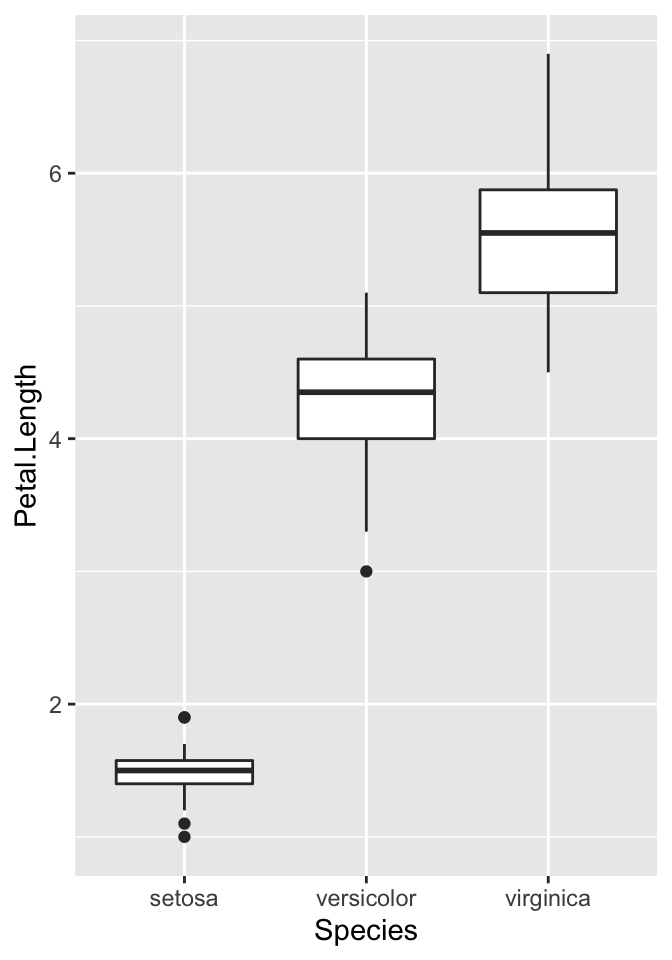

## Example

```r
iris %>% filter(Species == "setosa") %>% pull(Petal.Length) %>% shapiro.test()
```

```
##
##  Shapiro-Wilk normality test
##
## data:  .
## W = 0.95498, p-value = 0.05481
```

```r
iris %>% filter(Species == "versicolor") %>% pull(Petal.Length) %>% shapiro.test()
```

```
##
##  Shapiro-Wilk normality test
##
## data:  .
## W = 0.966, p-value = 0.1585
```

```r
iris %>% filter(Species == "virginica") %>% pull(Petal.Length) %>% shapiro.test()
```

```
##
##  Shapiro-Wilk normality test
##
## data:  .
## W = 0.96219, p-value = 0.1098
```

## T-test

Independent T-test tests whether two group means are different

\[outcome_i = (group\ mean) + error_i \]

- groups defined by a predictor, categorical variable
- outcome is a continuous variable
- assuming
  - normally distributed values in groups
  - homogeneity of variance of values in groups
    - if groups have different sizes
  - independence of groups

## Example

Values are normally distributed, groups have same size, and they are independent (different flowers, check using `leveneTest`)

```r
iris %>%
  filter(Species %in% c("versicolor", "virginica")) %$% # Note %$%
  t.test(Petal.Length ~ Species)
```

```
##
##  Welch Two Sample t-test
##
## data:  Petal.Length by Species
## t = -12.604, df = 95.57, p-value < 2.2e-16
## alternative hypothesis: true difference in means is not equal to 0
## 95 percent confidence interval:
##  -1.49549 -1.08851
## sample estimates:
## mean in group versicolor  mean in group virginica
##                    4.260                    5.552
```

The difference is significant t(95.57) = -12.6, *p* < .01

## ANOVA

ANOVA (analysis of variance) tests whether more than two group means are different

\[outcome_i = (group\ mean) + error_i \]

- groups defined by a predictor, categorical variable
- outcome is a continuous variable
- assuming
  - normally distributed values in groups
    - especially if groups have different sizes
  - homogeneity of variance of values in groups
    - if groups have different sizes
  - independence of groups

## Example

Values are normally distributed, groups have same size, they are independent (different flowers, check using `leveneTest`)

```r
iris %$%
  aov(Petal.Length ~ Species) %>%
  summary()
```

```
##              Df Sum Sq Mean Sq F value Pr(>F)
## Species       2  437.1  218.55    1180 <2e-16 ***
## Residuals   147   27.2    0.19
## ---
## Signif. codes:  0 '***' 0.001 '**' 0.01 '*' 0.05 '.' 0.1 ' ' 1
```

## Lecture 502 Correlation

## Correlation

Two variables can be related in three different ways

- related
  - positively: entities with high values in one tend to have high values in the other
  - negatively: entities with high values in one tend to have low values in the other
- not related at all

**Correlation** is a standardised measure of covariance

## Example

```r
flights_nov_20 <- nycflights13::flights %>%
  filter(!is.na(dep_delay), !is.na(arr_delay), month == 11, day ==20)
```

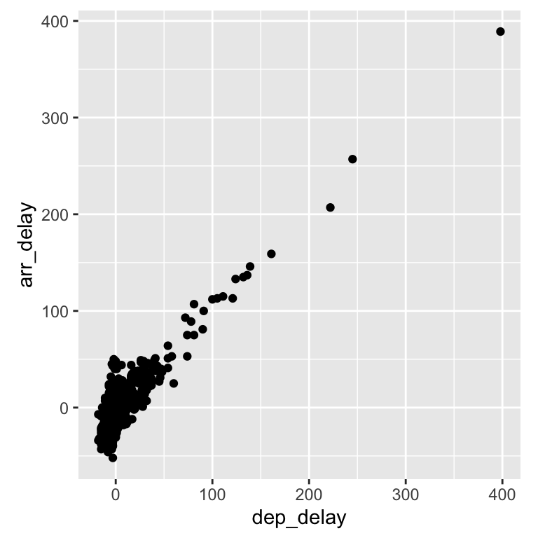

## Example

```r
flights_nov_20 %>%
  pull(dep_delay) %>% shapiro.test()
```

```
##
##  Shapiro-Wilk normality test
##
## data:  .
## W = 0.39881, p-value < 2.2e-16
```

```r
flights_nov_20 %>%
  pull(arr_delay) %>% shapiro.test()
```

```
##
##  Shapiro-Wilk normality test
##
## data:  .
## W = 0.67201, p-value < 2.2e-16
```

## Pearson’s r

If two variables are **normally distributed**, use **Pearson’s r**

The square of the correlation value indicates the percentage of shared variance

*If they were normally distributed, but they are not*

- 0.882 ^ 2 = 0.778
- departure and arrival delay *would* share 77.8% of variance

```r
# note the use of %$%
#instead of %>%
flights_nov_20 %$%
  cor.test(dep_delay, arr_delay)
```

```
##
##  Pearson's product-moment correlation
##
## data:  dep_delay and arr_delay
## t = 58.282, df = 972, p-value < 2.2e-16
## alternative hypothesis: true correlation is not equal to 0
## 95 percent confidence interval:
##  0.8669702 0.8950078
## sample estimates:
##       cor
## 0.8817655
```

## Spearman’s rho

If two variables are **not normally distributed**, use **Spearman’s rho**

- non-parametric
- based on rank difference

The square of the correlation value indicates the percentage of shared variance

*If few ties, but there are*

- 0.536 ^ 2 = 0.287
- departure and arrival delay *would* share 28.7% of variance

```r
flights_nov_20 %$%
  cor.test(
    dep_delay, arr_delay,
    method = "spearman")
```

```
##
##  Spearman's rank correlation rho
##
## data:  dep_delay and arr_delay
## S = 71437522, p-value < 2.2e-16
## alternative hypothesis: true rho is not equal to 0
## sample estimates:
##       rho
## 0.5361247
```

## Kendall’s tau

If **not normally distributed** and there is a **large number of ties**, use **Kendall’s tau**

- non-parametric
- based on rank difference

The square of the correlation value indicates the percentage of shared variance

**Departure and arrival delay seem actually to share**

- 0.396 ^ 2 = 0.157
- **15.7% of variance**

```r
flights_nov_20 %$%
  cor.test(
    dep_delay, arr_delay,
    method = "kendall")
```

```
##
##  Kendall's rank correlation tau
##
## data:  dep_delay and arr_delay
## z = 17.859, p-value < 2.2e-16
## alternative hypothesis: true tau is not equal to 0
## sample estimates:
##       tau
## 0.3956265
```